# GuideRefine: a tool to remove multi-target-/off-target sgRNAs from genome-wide CRISPR-KO screen libraries

Developed with R v4.5.2

Author: Stefanus Bernard

Date: 09 May 2026

# 1 Input data and Methods

## 1.1 Input data

1. sgRNA library TSV file input for MAGeCK (Format: sgRNA, spacer, gene; without header)
2. Reference genome indexed using bowtie tool (can be hg38 or T2T-CHM13)
3. CCDS annotation file. Look for the current release here: https://ftp.ncbi.nlm.nih.gov/pub/CCDS/current_human/
4. HGNC (Hugo Gene Nomenclature Committee) annotation file. Look for the current release here: https://www.genenames.org/download/custom/

The current HGNC dataset were retrieved from https://storage.googleapis.com/public-download-files/hgnc/tsv/tsv/hgnc_complete_set.txt

## 1.2 Methods

1. Import required packages
2. Define any filename
3. Import sgRNA library and create dir for output (output_cleaning) and intermediate files (object_intermediate)
4. Alignment of sgRNA to reference genome (hg38 or T2T-CHM13) using Bowtie via crisprBowtie (max 2 mismatches)
5. Post alignment data processing
6. Find and drop multi-target sgRNAs
7. Find and drop single mismatch sgRNAs (optional)
8. Find and drop sgRNA align with single mismatch at the PAM-distal
9. Find and drop sgRNA align with double mismatch at the PAM-distal
10. CCDS annotation of sgRNA library
11. HGNC annotation of sgRNA library
12. Clean sgRNA library
13. Discard any genes targeted by less than 3 sgRNAs
14. Calculate how many sgRNAs or genes lost
15. Export the refined sgRNA library TSV file and excel file report

# 2 Pipeline

## 2.1 Parameters for the pipeline

```
## [1] "sgRNA library name: broadgpp-brunello-library-contents"
```

```
## [1] "CCDS or .RDS file: annotation_file/T2T-CHM13v2.0_gene_annot_granges.rds"
```

```
## [1] "Genome version: T2T-CHM13v2.0"
```

## 2.2 Report of multi-target sgRNAs

```
## [1] "Number of multi-target sgRNAs: 3066"
```

```
## [1] "Number of genes lost due to multi-target sgRNAs: 346"
```

## 2.3 Report of single mismatch sgRNAs

```
## [1] "Number of single mismatch sgRNAs: 6240"
## [1] "Number of genes lost due to single mismatch sgRNAs: 437"
```

## 2.4 Report of PAM-distal mismatch sgRNAs

```
## [1] "Number of PAM-distal single mismatch sgRNAs: 0"
```

```
## [1] "Number of genes lost due to PAM-distal single mismatch sgRNAs: 0"
```

```
## [1] "Number of PAM-distal double mismatch sgRNAs: 118"
```

```
## [1] "Number of genes lost due to PAM-distal double mismatch sgRNAs: 3"
```

## 2.5 Validation of gene symbol for the alignment and annotation data

**Alignment validation to check whether there is a symbol mismatch between the gene symbol and the exon annotation**

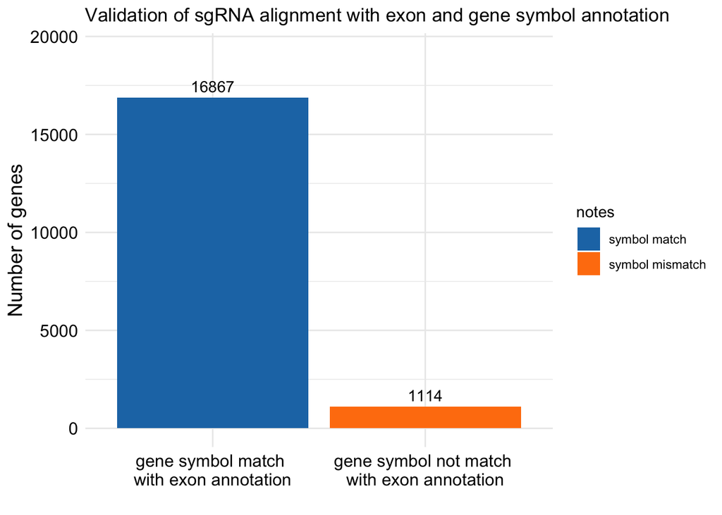

**Correct the sgRNA according to targeted gene symbol**

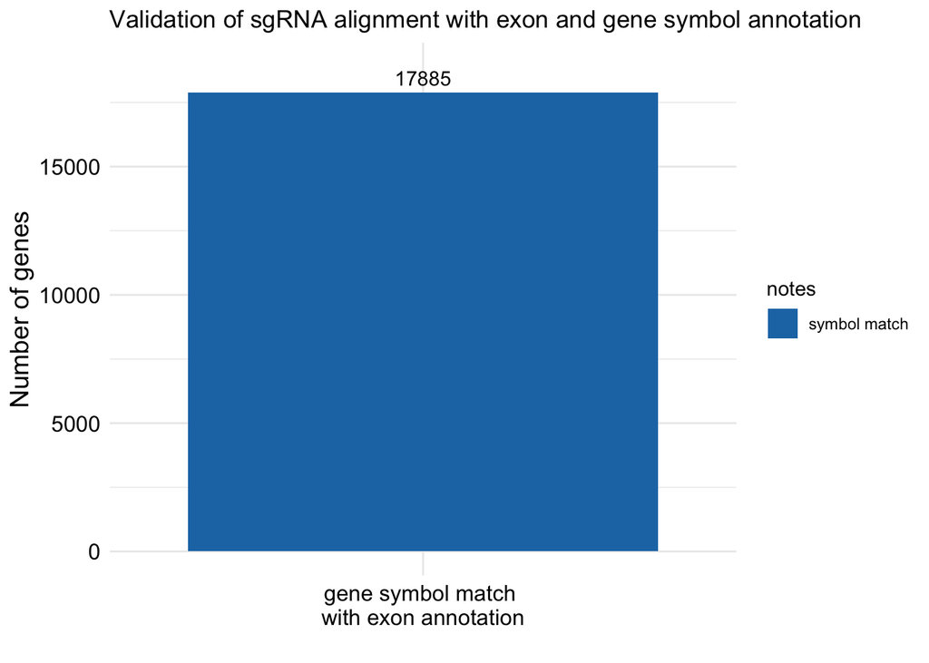

**Genes lost after annotation**

**Genes lost at this stage means that its sgRNA was not aligned to anywhere in the genome**

```
## [1] "number of genes lost following the annotation: 358"
```

**sgRNAs not targeting protein coding genes**

```
## [1] "number of non protein-coding genes: 100"
```

## 2.6 Final report of refined sgRNA library

[output not shown]

## 2.7 Export the refined library, sgRNA cleaning report, and list discarded sgRNA

- Export the refined sgRNA library (TSV file)
- Export the total sgRNA or gene lost (Excel file)